# An Introduction to Statistical Learning

Embarking on an exploration into the realm of data science, I’m immersing myself in ‘An Introduction to Statistical Learning with Applications in R’ by James, G., Witten, D., Hastie, T., and Tibshirani, R. (2013). Focused on chapters 3 and 4, I’ll replicate exercises within this enlightening book to uncover the secrets concealed within datasets.

Francisco Guzmán  
2023-11-14

## 3.6 Lab: Linear Regression

### 3.6.1 Libraries

```r
library(MASS)
library(ISLR)
```

### 3.6.2 Simple Linear Regression

```r
names(Boston)
```

```
 [1] "crim"    "zn"      "indus"   "chas"    "nox"     "rm"
 [7] "age"     "dis"     "rad"     "tax"     "ptratio" "black"
[13] "lstat"   "medv"
```

We will start by using the **lm()** function to fit a simple linear regression model, with $medv$ as the response and $lstat$ as the predictor. The basic syntax is **lm(y~x,data)**, where $y$ is the response, $x$ is the predictor, and data is the data set in which these two variables are kept.

```r
lm.fit=lm(medv~lstat, data=Boston)
```

For more detailed information, we use **summary(lm.fit)**.

```r
summary(lm.fit)
```

```
Call:
lm(formula = medv ~ lstat, data = Boston)

Residuals:
    Min      1Q  Median      3Q     Max
-15.168  -3.990  -1.318   2.034  24.500

Coefficients:
            Estimate Std. Error t value Pr(>|t|)
(Intercept) 34.55384    0.56263   61.41   <2e-16 ***
lstat       -0.95005    0.03873  -24.53   <2e-16 ***
---
Signif. codes:  0 '***' 0.001 '**' 0.01 '*' 0.05 '.' 0.1 ' ' 1

Residual standard error: 6.216 on 504 degrees of freedom
Multiple R-squared:  0.5441,    Adjusted R-squared:  0.5432
F-statistic: 601.6 on 1 and 504 DF,  p-value: < 2.2e-16
```

```r
coef(lm.fit)
```

```
(Intercept)       lstat
 34.5538409  -0.9500494
```

In order to obtain a confidence interval for the coefficient estimates, we can use the **confint()** command.

```r
confint(lm.fit)
```

```
                2.5 %     97.5 %
(Intercept) 33.448457 35.6592247
lstat       -1.026148 -0.8739505
```

The **predict()** function can be used to produce confidence intervals and prediction intervals for the prediction of $medv$ for a given value of $lstat$.

```r
predict(lm.fit, data.frame(lstat=c(5,10 ,15)), interval = "confidence")
```

```
       fit      lwr      upr
1 29.80359 29.00741 30.59978
2 25.05335 24.47413 25.63256
3 20.30310 19.73159 20.87461
```

```r
predict(lm.fit ,data.frame(lstat=c(5,10 ,15)), interval = "prediction")
```

```
       fit       lwr      upr
1 29.80359 17.565675 42.04151
2 25.05335 12.827626 37.27907
3 20.30310  8.077742 32.52846
```

We will now plot $medv$ and $lstat$ along with the least squares regression line using the **plot()** and **abline()** functions.

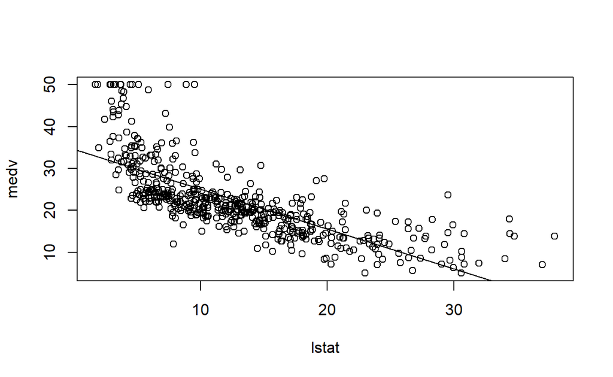

```r
attach(Boston)
plot(lstat, medv)
abline(lm.fit)
```

Below we experiment with some additional settings for plotting lines and points. The **lwd=3** command causes the width of the regression line to be increased by a factor of 3; this works for the **plot()** and **lines()** functions also. We can also use the **pch** option to create different plotting symbols.

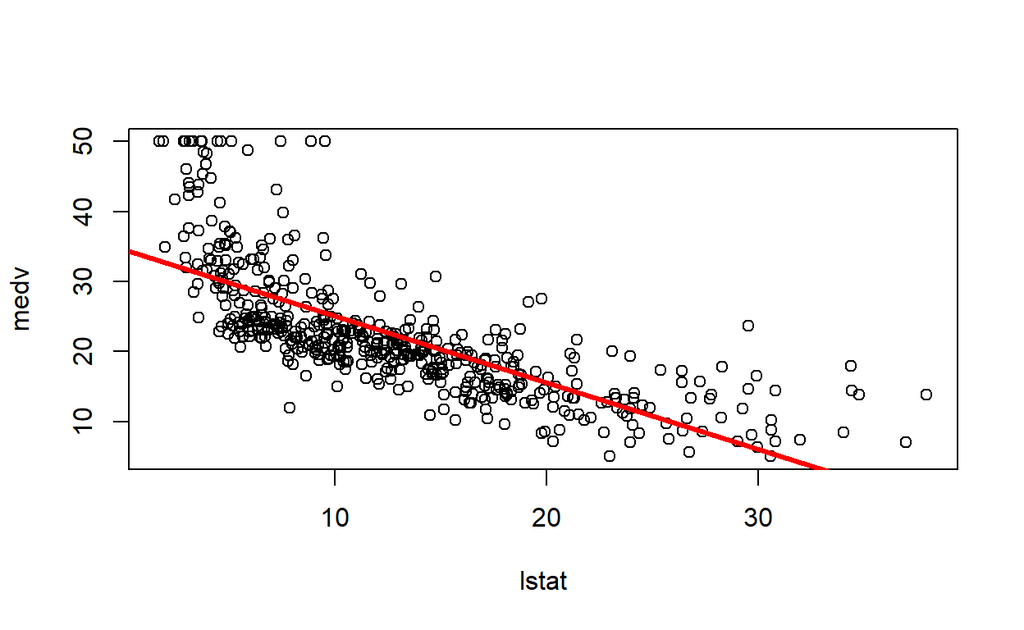

```r
plot(lstat, medv)
abline (lm.fit, lwd =3)
abline (lm.fit, lwd=3,col ="red")
```

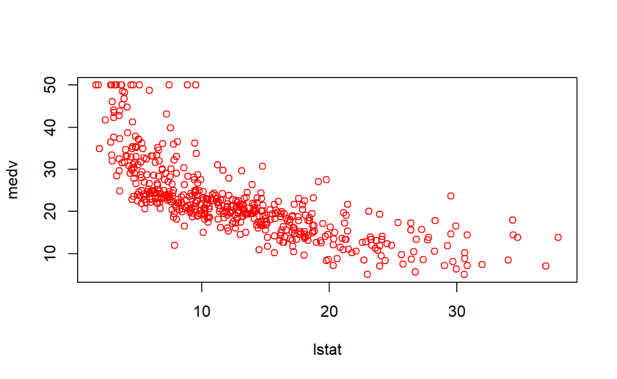

```r
plot(lstat, medv, col="red")
```

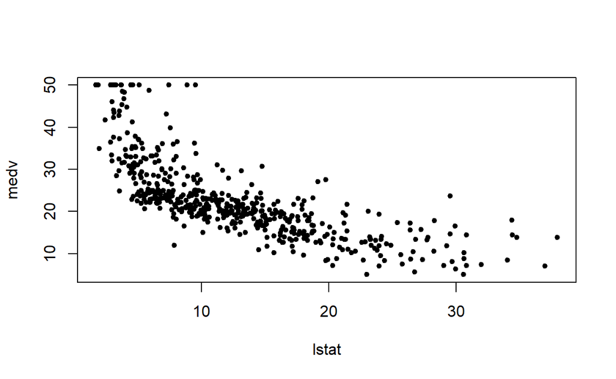

```r
plot(lstat, medv, pch =20)
```

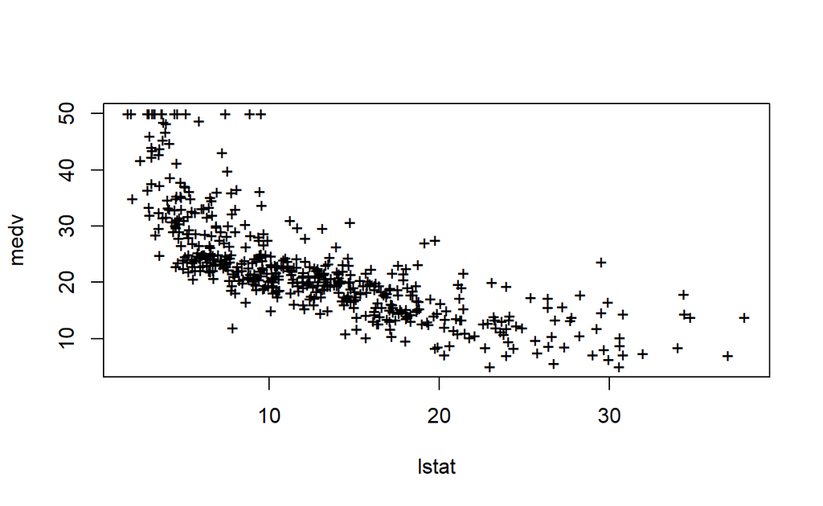

```r
plot(lstat, medv, pch ="+")
```

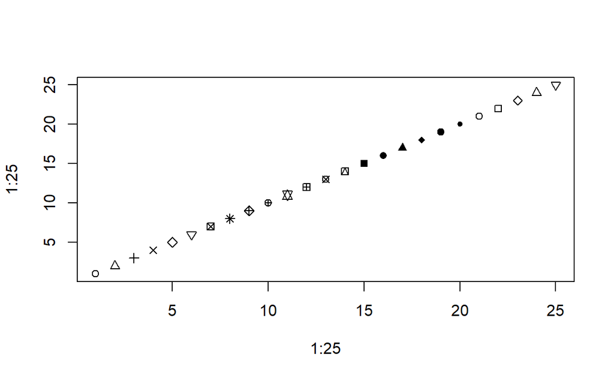

```r
plot(1:25,1:25, pch =1:25)
```

In general, **plot()** command will produce one plot at a time, and hitting *Enter* will generate the next plot. However, it is often convenient to view all four plots together. We can achieve this by using the **par()** function, which tells R to split the display screen into separate panels so that multiple plots can be viewed simultaneously. For example, **par(mfrow=c(2,2))** divides the plotting region into a 2 × 2 grid of panels.

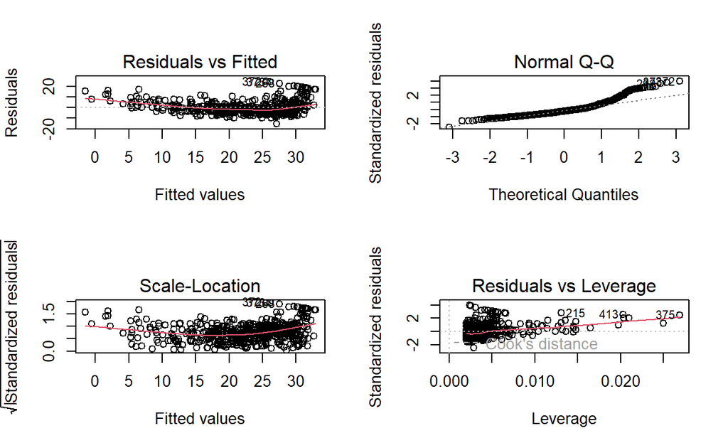

```r
par(mfrow=c(2,2))
plot(lm.fit)
```

Alternatively, we can compute the residuals from a linear regression fit using the **residuals()** function. The function **rstudent()** will return the studentized residuals, and we can use this function to plot the residuals against the fitted values.

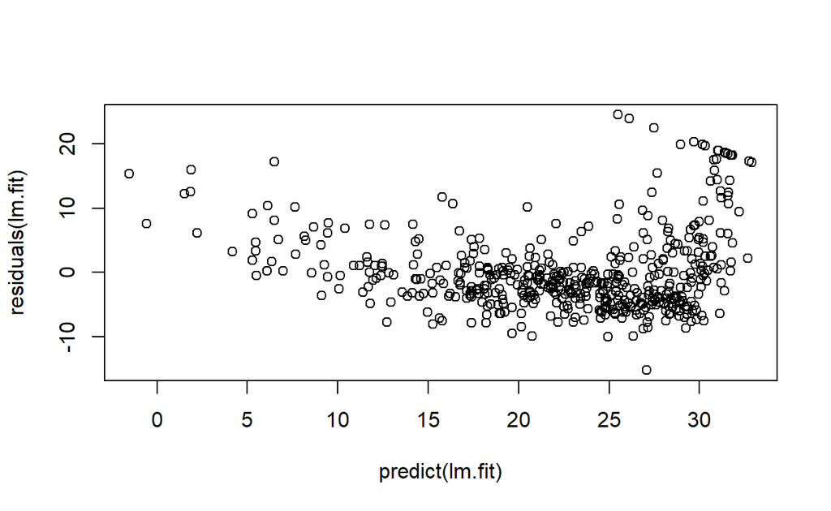

```r
plot(predict (lm.fit), residuals (lm.fit))
```

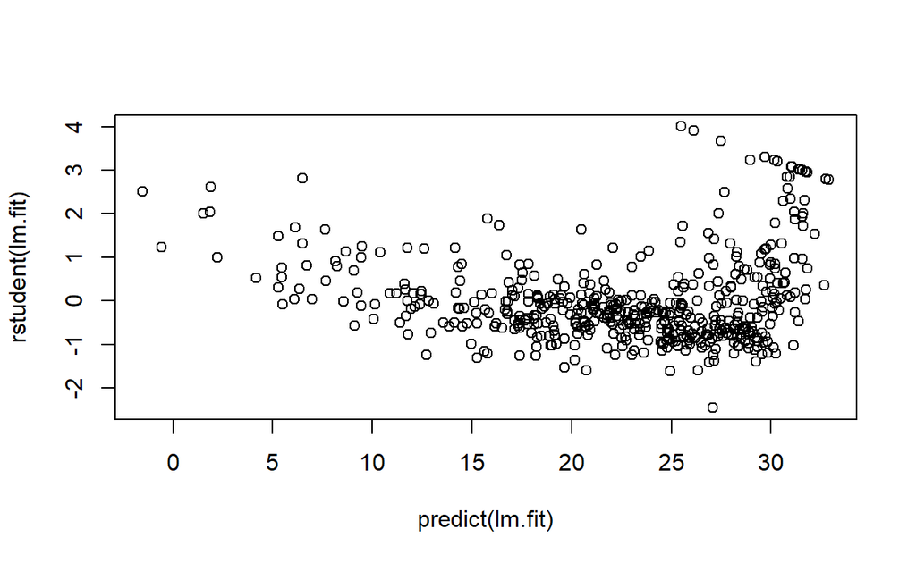

```r
plot(predict (lm.fit), rstudent (lm.fit))
```

On the basis of the residual plots, there is some evidence of non-linearity. Leverage statistics can be computed for any number of predictors using the **hatvalues()** function.

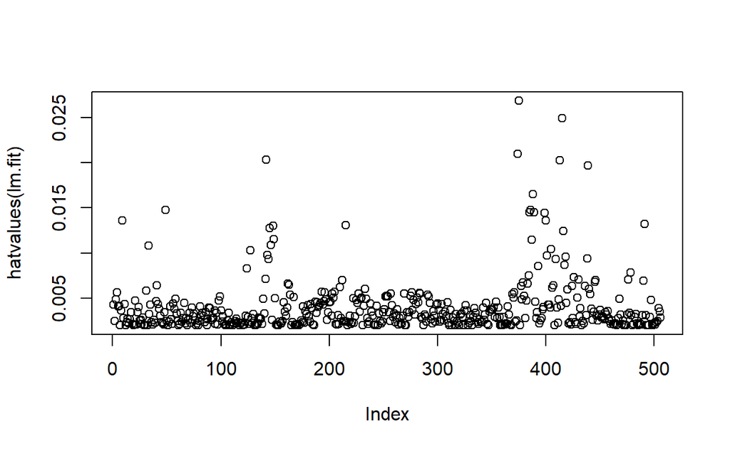

```r
plot(hatvalues (lm.fit))
```

```r
which.max(hatvalues (lm.fit))
```

```
375
375
```

The **which.max()** function identifies the index of the largest element of a vector. In this case, it tells us which observation has the largest leverage statistic.

### 3.6.3 Multiple Linear Regression

In order to fit a multiple linear regression model using least squares, we again use the **lm()** function. The syntax **lm(y~x1+x2+x3)** is used to fit a model with three predictors, $x1$, $x2$, and $x3$. The **summary()** function now outputs the regression coefficients for all the predictors.

```r
lm.fit=lm(medv~lstat+age, data=Boston)
summary (lm.fit)
```

```
Call:
lm(formula = medv ~ lstat + age, data = Boston)

Residuals:
    Min      1Q  Median      3Q     Max
-15.981  -3.978  -1.283   1.968  23.158

Coefficients:
            Estimate Std. Error t value Pr(>|t|)
(Intercept) 33.22276    0.73085  45.458  < 2e-16 ***
lstat       -1.03207    0.04819 -21.416  < 2e-16 ***
age          0.03454    0.01223   2.826  0.00491 **
---
Signif. codes:  0 '***' 0.001 '**' 0.01 '*' 0.05 '.' 0.1 ' ' 1

Residual standard error: 6.173 on 503 degrees of freedom
Multiple R-squared:  0.5513,    Adjusted R-squared:  0.5495
F-statistic:   309 on 2 and 503 DF,  p-value: < 2.2e-16
```

The **Boston** data set contains 13 variables, and so it would be cumbersome to have to type all of these in order to perform a regression using all of the predictors. Instead, we can use the following short-hand:

```r
lm.fit=lm(medv~.,data=Boston)
summary (lm.fit)
```

```
Call:
lm(formula = medv ~ ., data = Boston)

Residuals:
    Min      1Q  Median      3Q     Max
-15.595  -2.730  -0.518   1.777  26.199

Coefficients:
              Estimate Std. Error t value Pr(>|t|)
(Intercept)  3.646e+01  5.103e+00   7.144 3.28e-12 ***
crim        -1.080e-01  3.286e-02  -3.287 0.001087 **
zn           4.642e-02  1.373e-02   3.382 0.000778 ***
indus        2.056e-02  6.150e-02   0.334 0.738288
chas         2.687e+00  8.616e-01   3.118 0.001925 **
nox         -1.777e+01  3.820e+00  -4.651 4.25e-06 ***
rm           3.810e+00  4.179e-01   9.116  < 2e-16 ***
age          6.922e-04  1.321e-02   0.052 0.958229
dis         -1.476e+00  1.995e-01  -7.398 6.01e-13 ***
rad          3.060e-01  6.635e-02   4.613 5.07e-06 ***
tax         -1.233e-02  3.760e-03  -3.280 0.001112 **
ptratio     -9.527e-01  1.308e-01  -7.283 1.31e-12 ***
black        9.312e-03  2.686e-03   3.467 0.000573 ***
lstat       -5.248e-01  5.072e-02 -10.347  < 2e-16 ***
---
Signif. codes:  0 '***' 0.001 '**' 0.01 '*' 0.05 '.' 0.1 ' ' 1

Residual standard error: 4.745 on 492 degrees of freedom
Multiple R-squared:  0.7406,    Adjusted R-squared:  0.7338
F-statistic: 108.1 on 13 and 492 DF,  p-value: < 2.2e-16
```

The **vif()** function, part of the **car** package, can be used to compute variance inflation factors.

```r
vif(lm.fit)
```

```
    crim       zn    indus     chas      nox       rm      age
1.792192 2.298758 3.991596 1.073995 4.393720 1.933744 3.100826
     dis      rad      tax  ptratio    black    lstat
3.955945 7.484496 9.008554 1.799084 1.348521 2.941491
```

The following syntax results in a regression using all predictors except age.

```r
lm.fit1=lm(medv~.-age, data=Boston)
summary(lm.fit1)
```

```
Call:
lm(formula = medv ~ . - age, data = Boston)

Residuals:
     Min       1Q   Median       3Q      Max
-15.6054  -2.7313  -0.5188   1.7601  26.2243

Coefficients:
              Estimate Std. Error t value Pr(>|t|)
(Intercept)  36.436927   5.080119   7.172 2.72e-12 ***
crim         -0.108006   0.032832  -3.290 0.001075 **
zn            0.046334   0.013613   3.404 0.000719 ***
indus         0.020562   0.061433   0.335 0.737989
chas          2.689026   0.859598   3.128 0.001863 **
nox         -17.713540   3.679308  -4.814 1.97e-06 ***
rm            3.814394   0.408480   9.338  < 2e-16 ***
dis          -1.478612   0.190611  -7.757 5.03e-14 ***
rad           0.305786   0.066089   4.627 4.75e-06 ***
tax          -0.012329   0.003755  -3.283 0.001099 **
ptratio      -0.952211   0.130294  -7.308 1.10e-12 ***
black         0.009321   0.002678   3.481 0.000544 ***
lstat        -0.523852   0.047625 -10.999  < 2e-16 ***
---
Signif. codes:  0 '***' 0.001 '**' 0.01 '*' 0.05 '.' 0.1 ' ' 1

Residual standard error: 4.74 on 493 degrees of freedom
Multiple R-squared:  0.7406,    Adjusted R-squared:  0.7343
F-statistic: 117.3 on 12 and 493 DF,  p-value: < 2.2e-16
```

Alternatively, the **update()** function can be used.

```r
lm.fit1=update(lm.fit, ~.-age)
```

### 3.6.4 Interaction Terms

It is easy to include interaction terms in a linear model using the **lm()** function. The syntax **lstat:black** tells R to include an interaction term between $lstat$ and $black$. The syntax **lstat$*$age** simultaneously includes $lstat$, $age$, and the interaction term $lstat×age$ as predictors; it is a shorthand for **lstat+age+lstat:age**.

```r
summary (lm(medv~lstat*age, data=Boston))
```

```
Call:
lm(formula = medv ~ lstat * age, data = Boston)

Residuals:
    Min      1Q  Median      3Q     Max
-15.806  -4.045  -1.333   2.085  27.552

Coefficients:
              Estimate Std. Error t value Pr(>|t|)
(Intercept) 36.0885359  1.4698355  24.553  < 2e-16 ***
lstat       -1.3921168  0.1674555  -8.313 8.78e-16 ***
age         -0.0007209  0.0198792  -0.036   0.9711
lstat:age    0.0041560  0.0018518   2.244   0.0252 *
---
Signif. codes:  0 '***' 0.001 '**' 0.01 '*' 0.05 '.' 0.1 ' ' 1

Residual standard error: 6.149 on 502 degrees of freedom
Multiple R-squared:  0.5557,    Adjusted R-squared:  0.5531
F-statistic: 209.3 on 3 and 502 DF,  p-value: < 2.2e-16
```

### 3.6.5 Non-linear Transformations of the Predictors

The **lm()** function can also accommodate non-linear transformations of the predictors. For instance, given a predictor $X$, we can create a predictor $X^2$ using **I(X^2)**. The function **I()** is needed since the **^** has a special meaning in a formula; wrapping as we do allows the standard usage in R, which is to raise *$X$* to the power $2$. We now perform a regression of $medv$ onto $lstat$ and $lstat^2$.

```r
lm.fit2 = lm(medv ~ lstat + I(lstat^2))
summary(lm.fit2)
```

```
Call:
lm(formula = medv ~ lstat + I(lstat^2))

Residuals:
     Min       1Q   Median       3Q      Max
-15.2834  -3.8313  -0.5295   2.3095  25.4148

Coefficients:
             Estimate Std. Error t value Pr(>|t|)
(Intercept) 42.862007   0.872084   49.15   <2e-16 ***
lstat       -2.332821   0.123803  -18.84   <2e-16 ***
I(lstat^2)   0.043547   0.003745   11.63   <2e-16 ***
---
Signif. codes:  0 '***' 0.001 '**' 0.01 '*' 0.05 '.' 0.1 ' ' 1

Residual standard error: 5.524 on 503 degrees of freedom
Multiple R-squared:  0.6407,    Adjusted R-squared:  0.6393
F-statistic: 448.5 on 2 and 503 DF,  p-value: < 2.2e-16
```

The near-zero p-value associated with the quadratic term suggests that it leads to an improved model. We use the **anova()** function to further quantify the extent to which the quadratic fit is superior to the linear fit.

```r
lm.fit = lm(medv~lstat)
anova(lm.fit, lm.fit2)
```

```
Analysis of Variance Table

Model 1: medv ~ lstat
Model 2: medv ~ lstat + I(lstat^2)
  Res.Df   RSS Df Sum of Sq     F    Pr(>F)
1    504 19472
2    503 15347  1    4125.1 135.2 < 2.2e-16 ***
---
Signif. codes:  0 '***' 0.001 '**' 0.01 '*' 0.05 '.' 0.1 ' ' 1
```

Here Model 1 represents the linear submodel containing only one predictor, $lstat$, while Model 2 corresponds to the larger quadratic model that has two predictors, $lstat$ and $lstat^2$. The **anova()** function performs a hypothesis test comparing the two models. The null hypothesis is that the two models fit the data equally well, and the alternative hypothesis is that the full model is superior. Here the F-statistic is 135 and the associated p-value is virtually zero. This provides very clear evidence that the model containing the predictors $lstat$ and $lstat^2$ is far superior to the model that only contains the predictor $lstat$. This is not surprising, since earlier we saw evidence for non-linearity in the relationship between $medv$ and $lstat$. If we type

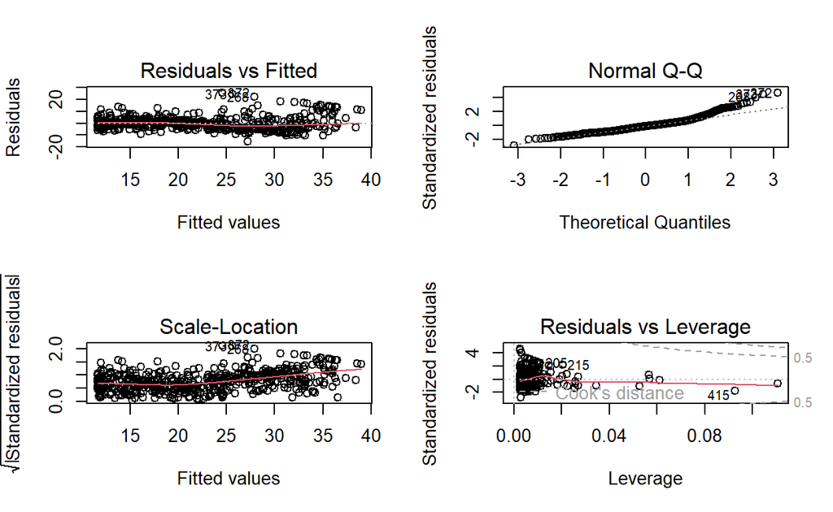

```r
par(mfrow=c(2,2))
plot(lm.fit2)
```

then we see that when the $lstat^2$ term is included in the model, there is little discernible pattern in the residuals.

In order to create a cubic fit, we can include a predictor of the form **I(X^3)**. However, this approach can start to get cumbersome for higher-order polynomials. A better approach involves using the **poly()** function to create the polynomial within **lm()**. For example, the following command produces a fifth-order polynomial fit:

```r
lm.fit5=lm(medv ~ poly(lstat ,5))
summary (lm.fit5)
```

```
Call:
lm(formula = medv ~ poly(lstat, 5))

Residuals:
     Min       1Q   Median       3Q      Max
-13.5433  -3.1039  -0.7052   2.0844  27.1153

Coefficients:
                 Estimate Std. Error t value Pr(>|t|)
(Intercept)       22.5328     0.2318  97.197  < 2e-16 ***
poly(lstat, 5)1 -152.4595     5.2148 -29.236  < 2e-16 ***
poly(lstat, 5)2   64.2272     5.2148  12.316  < 2e-16 ***
poly(lstat, 5)3  -27.0511     5.2148  -5.187 3.10e-07 ***
poly(lstat, 5)4   25.4517     5.2148   4.881 1.42e-06 ***
poly(lstat, 5)5  -19.2524     5.2148  -3.692 0.000247 ***
---
Signif. codes:  0 '***' 0.001 '**' 0.01 '*' 0.05 '.' 0.1 ' ' 1

Residual standard error: 5.215 on 500 degrees of freedom
Multiple R-squared:  0.6817,    Adjusted R-squared:  0.6785
F-statistic: 214.2 on 5 and 500 DF,  p-value: < 2.2e-16
```

This suggests that including additional polynomial terms, up to fifth order, leads to an improvement in the model fit! However, further investigation of the data reveals that no polynomial terms beyond fifth order have significant p-values in a regression fit.

Of course, we are in no way restricted to using polynomial transformations of the predictors. Here we try a log transformation

```r
 summary(lm(medv~log(rm),data=Boston))
```

```
Call:
lm(formula = medv ~ log(rm), data = Boston)

Residuals:
    Min      1Q  Median      3Q     Max
-19.487  -2.875  -0.104   2.837  39.816

Coefficients:
            Estimate Std. Error t value Pr(>|t|)
(Intercept)  -76.488      5.028  -15.21   <2e-16 ***
log(rm)       54.055      2.739   19.73   <2e-16 ***
---
Signif. codes:  0 '***' 0.001 '**' 0.01 '*' 0.05 '.' 0.1 ' ' 1

Residual standard error: 6.915 on 504 degrees of freedom
Multiple R-squared:  0.4358,    Adjusted R-squared:  0.4347
F-statistic: 389.3 on 1 and 504 DF,  p-value: < 2.2e-16
```

### 3.6.6 Qualitative Predictors

We will now examine the **Carseats** data, which is part of the **ISLR** library. We will attempt to predict $Sales$ (child car seat sales) in 400 locations based on a number of predictors.

```r
names(Carseats)
```

```
 [1] "Sales"       "CompPrice"   "Income"      "Advertising"
 [5] "Population"  "Price"       "ShelveLoc"   "Age"
 [9] "Education"   "Urban"       "US"
```

The **Carseats** data includes qualitative predictors such as $Shelveloc$, an indicator of the quality of the shelving location —that is, the space within a store in which the car seat is displayed— at each location. The predictor $Shelveloc$ takes on three possible values, *Bad*, *Medium*, and *Good*.

Given a qualitative variable such as $Shelveloc$, R generates dummy variables automatically. Below we fit a multiple regression model that includes some interaction terms.

```r
lm.fit=lm(Sales~.+Income:Advertising + Price:Age,data=Carseats)
summary (lm.fit)
```

```
Call:
lm(formula = Sales ~ . + Income:Advertising + Price:Age, data = Carseats)

Residuals:
    Min      1Q  Median      3Q     Max
-2.9208 -0.7503  0.0177  0.6754  3.3413

Coefficients:
                     Estimate Std. Error t value Pr(>|t|)
(Intercept)         6.5755654  1.0087470   6.519 2.22e-10 ***
CompPrice           0.0929371  0.0041183  22.567  < 2e-16 ***
Income              0.0108940  0.0026044   4.183 3.57e-05 ***
Advertising         0.0702462  0.0226091   3.107 0.002030 **
Population          0.0001592  0.0003679   0.433 0.665330
Price              -0.1008064  0.0074399 -13.549  < 2e-16 ***
ShelveLocGood       4.8486762  0.1528378  31.724  < 2e-16 ***
ShelveLocMedium     1.9532620  0.1257682  15.531  < 2e-16 ***
Age                -0.0579466  0.0159506  -3.633 0.000318 ***
Education          -0.0208525  0.0196131  -1.063 0.288361
UrbanYes            0.1401597  0.1124019   1.247 0.213171
USYes              -0.1575571  0.1489234  -1.058 0.290729
Income:Advertising  0.0007510  0.0002784   2.698 0.007290 **
Price:Age           0.0001068  0.0001333   0.801 0.423812
---
Signif. codes:  0 '***' 0.001 '**' 0.01 '*' 0.05 '.' 0.1 ' ' 1

Residual standard error: 1.011 on 386 degrees of freedom
Multiple R-squared:  0.8761,    Adjusted R-squared:  0.8719
F-statistic:   210 on 13 and 386 DF,  p-value: < 2.2e-16
```

The **contrasts()** function returns the coding that R uses for the dummy variables.

```r
attach(Carseats)
contrasts(ShelveLoc)
```

```
       Good Medium
Bad       0      0
Good      1      0
Medium    0      1
```

R has created a $ShelveLocGood$ dummy variable that takes on a value of 1 if the shelving location is good, and 0 otherwise. It has also created a $ShelveLocMedium$ dummy variable that equals 1 if the shelving location is medium, and 0 otherwise. A bad shelving location corresponds to a zero for each of the two dummy variables. The fact that the coefficient for $ShelveLocGood$ in the regression output is positive indicates that a good shelving location is associated with high sales (relative to a bad location). And $ShelveLocMedium$ has a smaller positive coefficient, indicating that a medium shelving location leads to higher sales than a bad shelving location but lower sales than a good shelving location.

### 3.6.7 Writing Functions

As we have seen, R comes with many useful functions, and still more functions are available by way of R libraries. However, we will often be interested in performing an operation for which no function is available. In this setting, we may want to write our own function. For instance, below we provide a simple function that reads in the **ISLR** and **MASS** libraries, called **LoadLibraries()**.

```r
LoadLibraries = function(){
  library(ISLR)
  library(MASS)
  print("The libraries have been loaded.")
 }
```

Now if we type in **LoadLibraries**, R will tell us what is in the function.

```r
LoadLibraries
```

```
function(){
  library(ISLR)
  library(MASS)
  print("The libraries have been loaded.")
 }
```

If we call the function, the libraries are loaded in and the print statement is output.

```r
LoadLibraries()
```

```
[1] "The libraries have been loaded."
```

## 4.6 Lab

### 4.6.1 The Stock Market Data

```r
library(ISLR)
str(Smarket)
```

```
'data.frame':   1250 obs. of  9 variables:
 $ Year     : num  2001 2001 2001 2001 2001 ...
 $ Lag1     : num  0.381 0.959 1.032 -0.623 0.614 ...
 $ Lag2     : num  -0.192 0.381 0.959 1.032 -0.623 ...
 $ Lag3     : num  -2.624 -0.192 0.381 0.959 1.032 ...
 $ Lag4     : num  -1.055 -2.624 -0.192 0.381 0.959 ...
 $ Lag5     : num  5.01 -1.055 -2.624 -0.192 0.381 ...
 $ Volume   : num  1.19 1.3 1.41 1.28 1.21 ...
 $ Today    : num  0.959 1.032 -0.623 0.614 0.213 ...
 $ Direction: Factor w/ 2 levels "Down","Up": 2 2 1 2 2 2 1 2 2 2 ...
```

```r
summary(Smarket)
```

```
      Year           Lag1                Lag2
 Min.   :2001   Min.   :-4.922000   Min.   :-4.922000
 1st Qu.:2002   1st Qu.:-0.639500   1st Qu.:-0.639500
 Median :2003   Median : 0.039000   Median : 0.039000
 Mean   :2003   Mean   : 0.003834   Mean   : 0.003919
 3rd Qu.:2004   3rd Qu.: 0.596750   3rd Qu.: 0.596750
 Max.   :2005   Max.   : 5.733000   Max.   : 5.733000
      Lag3                Lag4                Lag5
 Min.   :-4.922000   Min.   :-4.922000   Min.   :-4.92200
 1st Qu.:-0.640000   1st Qu.:-0.640000   1st Qu.:-0.64000
 Median : 0.038500   Median : 0.038500   Median : 0.03850
 Mean   : 0.001716   Mean   : 0.001636   Mean   : 0.00561
 3rd Qu.: 0.596750   3rd Qu.: 0.596750   3rd Qu.: 0.59700
 Max.   : 5.733000   Max.   : 5.733000   Max.   : 5.73300
     Volume           Today           Direction
 Min.   :0.3561   Min.   :-4.922000   Down:602
 1st Qu.:1.2574   1st Qu.:-0.639500   Up  :648
 Median :1.4229   Median : 0.038500
 Mean   :1.4783   Mean   : 0.003138
 3rd Qu.:1.6417   3rd Qu.: 0.596750
 Max.   :3.1525   Max.   : 5.733000
```

```r
cor(Smarket [,-9])
```

```
             Year         Lag1         Lag2         Lag3         Lag4
Year   1.00000000  0.029699649  0.030596422  0.033194581  0.035688718
Lag1   0.02969965  1.000000000 -0.026294328 -0.010803402 -0.002985911
Lag2   0.03059642 -0.026294328  1.000000000 -0.025896670 -0.010853533
Lag3   0.03319458 -0.010803402 -0.025896670  1.000000000 -0.024051036
Lag4   0.03568872 -0.002985911 -0.010853533 -0.024051036  1.000000000
Lag5   0.02978799 -0.005674606 -0.003557949 -0.018808338 -0.027083641
Volume 0.53900647  0.040909908 -0.043383215 -0.041823686 -0.048414246
Today  0.03009523 -0.026155045 -0.010250033 -0.002447647 -0.006899527
               Lag5      Volume        Today
Year    0.029787995  0.53900647  0.030095229
Lag1   -0.005674606  0.04090991 -0.026155045
Lag2   -0.003557949 -0.04338321 -0.010250033
Lag3   -0.018808338 -0.04182369 -0.002447647
Lag4   -0.027083641 -0.04841425 -0.006899527
Lag5    1.000000000 -0.02200231 -0.034860083
Volume -0.022002315  1.00000000  0.014591823
Today  -0.034860083  0.01459182  1.000000000
```

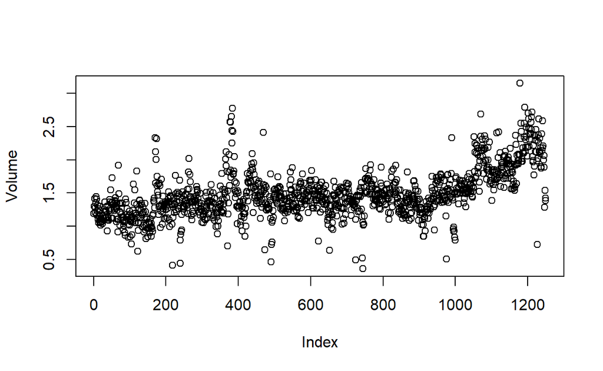

```r
attach(Smarket)
plot(Volume)
```

### 4.6.2 Logistic Regression

```r
glm.fit = glm(Direction ~ Lag1 + Lag2 + Lag3 + Lag4 + Lag5 + Volume,
data = Smarket, family = binomial)
summary(glm.fit)
```

```
Call:
glm(formula = Direction ~ Lag1 + Lag2 + Lag3 + Lag4 + Lag5 +
    Volume, family = binomial, data = Smarket)

Deviance Residuals:
   Min      1Q  Median      3Q     Max
-1.446  -1.203   1.065   1.145   1.326

Coefficients:
             Estimate Std. Error z value Pr(>|z|)
(Intercept) -0.126000   0.240736  -0.523    0.601
Lag1        -0.073074   0.050167  -1.457    0.145
Lag2        -0.042301   0.050086  -0.845    0.398
Lag3         0.011085   0.049939   0.222    0.824
Lag4         0.009359   0.049974   0.187    0.851
Lag5         0.010313   0.049511   0.208    0.835
Volume       0.135441   0.158360   0.855    0.392

(Dispersion parameter for binomial family taken to be 1)

    Null deviance: 1731.2  on 1249  degrees of freedom
Residual deviance: 1727.6  on 1243  degrees of freedom
AIC: 1741.6

Number of Fisher Scoring iterations: 3
```

```r
coef(glm.fit)
```

```
 (Intercept)         Lag1         Lag2         Lag3         Lag4
-0.126000257 -0.073073746 -0.042301344  0.011085108  0.009358938
        Lag5       Volume
 0.010313068  0.135440659
```

```r
summary(glm.fit)$coef
```

```
                Estimate Std. Error    z value  Pr(>|z|)
(Intercept) -0.126000257 0.24073574 -0.5233966 0.6006983
Lag1        -0.073073746 0.05016739 -1.4565986 0.1452272
Lag2        -0.042301344 0.05008605 -0.8445733 0.3983491
Lag3         0.011085108 0.04993854  0.2219750 0.8243333
Lag4         0.009358938 0.04997413  0.1872757 0.8514445
Lag5         0.010313068 0.04951146  0.2082966 0.8349974
Volume       0.135440659 0.15835970  0.8552723 0.3924004
```

```r
summary(glm.fit)$coef[,4] # Para obtener sólo los p-values
```

```
(Intercept)        Lag1        Lag2        Lag3        Lag4
  0.6006983   0.1452272   0.3983491   0.8243333   0.8514445
       Lag5      Volume
  0.8349974   0.3924004
```

Probabilidad de que el mercado vaya al alza.

```r
glm.probs = predict(glm.fit, type = "response")
glm.probs[1:10]
```

```
        1         2         3         4         5         6         7
0.5070841 0.4814679 0.4811388 0.5152224 0.5107812 0.5069565 0.4926509
        8         9        10
0.5092292 0.5176135 0.4888378
```

```r
contrasts(Direction)
```

```
     Up
Down  0
Up    1
```

```r
glm.pred = rep("Down", 1250)
glm.pred[glm.probs >.5] = "Up"
table(glm.pred, Direction)
```

```
        Direction
glm.pred Down  Up
    Down  145 141
    Up    457 507
```

Los elementos de las diagonales indican predicciones correctas, el resto son predicciones incorrectas.

```r
mean(glm.pred==Direction) #Predicciones correctas
```

```
[1] 0.5216
```

Creamos un vector para las obs desde 2001 a 2004, a continuación, utilizaremos este vector para crear un conjunto de datos para las observaciones de 2005.

```r
train = (Year < 2005)
Smarket.2005 = Smarket[!train,]
dim(Smarket.2005)
```

```
[1] 252   9
```

```r
Direction.2005 = Direction[!train]
```

```r
glm.fit= glm (Direction ~ Lag1 + Lag2 + Lag3 + Lag4 + Lag5 + Volume,
              data = Smarket, family = binomial, subset = train)
glm.probs = predict(glm.fit, Smarket.2005, type = "response")
```

```r
glm.pred = rep("Down", 252)
glm.pred[glm.probs >.5]= "Up"
table(glm.pred, Direction.2005)
```

```
        Direction.2005
glm.pred Down Up
    Down   77 97
    Up     34 44
```

```r
mean(glm.pred == Direction.2005)
```

```
[1] 0.4801587
```

```r
mean(glm.pred != Direction.2005)
```

```
[1] 0.5198413
```

Ajustamos la regresión logística utilizando sólo $Lag1$ y $Lag2$, que parecían tener el mayor poder de predicción en el modelo de regresión logística original.

```r
glm.fit = glm(Direction ~ Lag1 + Lag2, data = Smarket, family = binomial,
            subset=train)
glm.probs = predict(glm.fit, Smarket.2005, type= "response")
glm.pred = rep("Down", 252)
glm.pred[glm.probs >.5] = "Up"
table(glm.pred, Direction.2005)
```

```
        Direction.2005
glm.pred Down  Up
    Down   35  35
    Up     76 106
```

```r
mean(glm.pred==Direction.2005)
```

```
[1] 0.5595238
```

```r
predict(glm.fit, newdata = data.frame(Lag1=c(1.2 ,1.5),
                                      Lag2=c(1.1,-0.8)),
        type="response")
```

```
        1         2
0.4791462 0.4960939
```